# Integrating proteomics data

Pratheepa Jeganathan, Susan Holmes

07 March, 2020

# Contents

- Wagner 2018 Cytof
- 140 breast cancer patients; Of 140, 6 tripple negative (TN)
- cd45_sce_dropna$Clinical.Subtype == “TN
- 3 cancer-free
- 73 protein markers in immune-centric and tumor-centric microenvironment
- Keren 2018 Multiplex Ion Bean Imaging (MIBI)
- Tumor-immune microenvironment in TN patients
- 41 TN patients
- 36 proteins

We will choose patients with TN and immune cells in both CyTOF and MIBI for the integrative analysis.

```r
K = params$K
K
```

```
## [1] 10
```

```r
iter = params$R
iter
```

```
## [1] 2000
```

```r
#library(flowCore)
library(SingleCellExperiment)
library(ggplot2)
library(rstan)
#library(scater)
library(plyr)
library(reshape2)
library(readr)
#library(CATALYST)
library(magrittr)
#library(scMerge)
library(MultiAssayExperiment)
library(dplyr)
library(DESeq2)
library(abind)
library(tibble)
library(RColorBrewer)
```

# 1 Mass-Tag CyTOF Breast Cancer Data

```r
# load("./Data/masstagSCE.rda")
# cd45.sce # 38 * 426872
# rm(epith.sce, livecells.sce, myeloid.sce, tcell.sce)
```

Drop the five subjects without any clinical data. We can use Gender variable to identify those subejcts

```r
# unique(colData(cd45.sce)$patient_id.y[which(is.na(colData(cd45.sce)$Gender))])

# cd45_to_keep <- which(!is.na(colData(cd45.sce)$Gender))
# cd45.sce_dropna <- cd45.sce[,cd45_to_keep]
# cd45.sce_dropna # 38 * 420685
# # To verify there are no (true) NA's left:
# sum(is.na(rowData(cd45.sce_dropna)))
# rm(cd45.sce, cd45_to_keep)
```

```r
#saveRDS(cd45.sce_dropna, "./Data/cd45_sce_dropna.rds")
cd45_sce_dropna = readRDS("./Data/cd45_sce_dropna.rds")
```

# 2 Keren et al., MIBI-TOF Breast Cancer Data

- All the patients were TN
- The size-normalized raw intensity values are then arcsinh transformed and standardized across the markers.

```r
load('./Data/mibiSCE.rda')
mibi.sce
```

```
## class: SingleCellExperiment
## dim: 49 201656
## metadata(0):
## assays(1): mibi_exprs
## rownames(49): C Na ... Ta Au
## rowData names(4): channel_name is_protein hgnc_symbol wagner_overlap
## colnames: NULL
## colData names(36): SampleID cellLabelInImage ...
##   Survival_days_capped_2016.1.1 Censored
## reducedDimNames(0):
## spikeNames(0):
## altExpNames(0):
```

Rows correspond to channels and columns correspond to cells. We can see all of the channels that were collected in this experiment:

```r
rownames(mibi.sce)
```

```
##  [1] "C"            "Na"           "Si"           "P"            "Ca"
##  [6] "Fe"           "dsDNA"        "Vimentin"     "SMA"          "Background"
## [11] "B7H3"         "FoxP3"        "Lag3"         "CD4"          "CD16"
## [16] "CD56"         "OX40"         "PD1"          "CD31"         "PD-L1"
## [21] "EGFR"         "Ki67"         "CD209"        "CD11c"        "CD138"
## [26] "CD163"        "CD68"         "CSF-1R"       "CD8"          "CD3"
## [31] "IDO"          "Keratin17"    "CD63"         "CD45RO"       "CD20"
## [36] "p53"          "Beta catenin" "HLA-DR"       "CD11b"        "CD45"
## [41] "H3K9ac"       "Pan-Keratin"  "H3K27me3"     "phospho-S6"   "MPO"
## [46] "Keratin6"     "HLA_Class_1"  "Ta"           "Au"
```

The 38 proteins can be easily identified by using the binary attribute is_protein from rowData:

```r
proteins = rowData(mibi.sce)$is_protein==1
sum(proteins)
```

```
## [1] 38
```

```r
mibi.sce_proteins <- mibi.sce[which(proteins),]
mibi.sce_proteins
```

```
## class: SingleCellExperiment
## dim: 38 201656
## metadata(0):
## assays(1): mibi_exprs
## rownames(38): Vimentin B7H3 ... Keratin6 HLA_Class_1
## rowData names(4): channel_name is_protein hgnc_symbol wagner_overlap
## colnames: NULL
## colData names(36): SampleID cellLabelInImage ...
##   Survival_days_capped_2016.1.1 Censored
## reducedDimNames(0):
## spikeNames(0):
## altExpNames(0):
```

```r
rownames(mibi.sce_proteins)
```

```
##  [1] "Vimentin"     "B7H3"         "FoxP3"        "Lag3"         "CD4"
##  [6] "CD16"         "CD56"         "OX40"         "PD1"          "CD31"
## [11] "PD-L1"        "EGFR"         "Ki67"         "CD209"        "CD11c"
## [16] "CD138"        "CD163"        "CD68"         "CSF-1R"       "CD8"
## [21] "CD3"          "IDO"          "Keratin17"    "CD63"         "CD45RO"
## [26] "CD20"         "p53"          "Beta catenin" "HLA-DR"       "CD11b"
## [31] "CD45"         "H3K9ac"       "Pan-Keratin"  "H3K27me3"     "phospho-S6"
## [36] "MPO"          "Keratin6"     "HLA_Class_1"
```

```r
rm(mibi.sce)
```

Cell type information is availble in the columns *tumor_group* and *immune_group*

51% of cells were Keratin positive tumor cells and 41% of cells were immune cells.

```r
round(table(mibi.sce_proteins$tumor_group)/ncol(mibi.sce_proteins),2)
```

```
##
##            Endothelial                 Immune Keratin-positive tumor
##                   0.01                   0.41                   0.51
##       Mesenchymal-like                  Tumor           Unidentified
##                   0.04                   0.02                   0.01
```

Among the immune cell population, macrophages and CD8, CD4+ T-cells and other immune cells were identified. 10% of all cells assayed were macrophages

```r
# Immune Cells
round(table(mibi.sce_proteins$immune_group)/ncol(mibi.sce_proteins),2)
```

```
##
##            B          CD3          CD4          CD8           DC      DC/Mono
##         0.05         0.02         0.06         0.08         0.01         0.03
##  Macrophages     Mono/Neu  Neutrophils           NK   not immune Other immune
##         0.10         0.02         0.01         0.00         0.59         0.03
##        Tregs
##         0.01
```

These fields can be used to subset by cell and/or sample characteristic. E.g., below we subset only for the 83,336 cells identified as immune.

```r
immune_inds <- which(mibi.sce_proteins$tumor_group == "Immune")
mibi.sce_immune <- mibi.sce_proteins[,immune_inds]
mibi.sce_immune
```

```
## class: SingleCellExperiment
## dim: 38 83336
## metadata(0):
## assays(1): mibi_exprs
## rownames(38): Vimentin B7H3 ... Keratin6 HLA_Class_1
## rowData names(4): channel_name is_protein hgnc_symbol wagner_overlap
## colnames: NULL
## colData names(36): SampleID cellLabelInImage ...
##   Survival_days_capped_2016.1.1 Censored
## reducedDimNames(0):
## spikeNames(0):
## altExpNames(0):
```

```r
mibi_sce_immune <- mibi.sce_immune

rm(mibi.sce_proteins, mibi.sce_immune)
```

There are three protein without gene symbol in cd45_sce_dropna so we drop them

```r
Proteins_in_cd45 <- !(rowData(cd45_sce_dropna)$hgnc_symbol == "na")

cd45_sce_dropna <- cd45_sce_dropna[which(Proteins_in_cd45),]
cd45_sce_dropna
```

```
## class: SingleCellExperiment
## dim: 35 420685
## metadata(0):
## assays(1): exprs
## rownames(35): CD64 CD38 ... CD8a CD45
## rowData names(4): channel_name marker_name marker_class hgnc_symbol
## colnames: NULL
## colData names(31): sample_id condition.x ...
##   Neoadjuvant.Therapy.Received Previous.Cancer.Incidences
## reducedDimNames(0):
## spikeNames(0):
## altExpNames(0):
```

Proteins in both CD45 cells from the live cells (assayed on immune panel) and donor immune cells

```r
sum(rownames(cd45_sce_dropna) %in% rownames(mibi_sce_immune))
```

```
## [1] 9
```

```r
rownames(cd45_sce_dropna)[which(rownames(cd45_sce_dropna) %in% rownames(mibi_sce_immune))]
```

```
## [1] "CD68"  "CD20"  "CD11b" "CD4"   "CD16"  "CD163" "CD3"   "CD11c" "CD45"
```

## 2.1 Merge two SingleCellExperiment objects and make mae

```r
# 148 patients
se_cd45 <- SummarizedExperiment(
  assays = list(exprs = assay(cd45_sce_dropna)),
  colData = colData(cd45_sce_dropna),
  rowData = rowData(cd45_sce_dropna)
)

# Subset CD45 cells from the live cells from TN patients

se_cd45 <- se_cd45[, colData(se_cd45)$Clinical.Subtype == "TN"]
se_cd45 <- se_cd45[, colSums(assay(se_cd45)) > 0]

se_mibi <- SummarizedExperiment(
  assays = list(exprs = assay(mibi_sce_immune)),
  colData = colData(mibi_sce_immune),
  rowData = rowData(mibi_sce_immune)
)

se_mibi <- se_mibi[, colSums(assay(se_mibi)) > 0]
```

```r
names(colData(se_cd45))[1:3] <- c("SampleID", "Condition", "PatientID")
names(colData(se_mibi))[c(1,9)] <- c("SampleID", "PatientID")

colData(se_cd45)$SampleID <- paste0(seq(1: length(colData(se_cd45)$SampleID)), "_", colData(se_cd45)$PatientID)

colData(se_mibi)$SampleID <- paste0(seq(1: length(colData(se_mibi)$SampleID)), "_", colData(se_mibi)$PatientID)

rownames(colData(se_cd45)) <- colData(se_cd45)$SampleID
rownames(colData(se_mibi)) <- colData(se_mibi)$SampleID
```

Subset for the initial analysis

```r
# se_cd45 <- se_cd45[, colData(se_cd45)$PatientID == "BB028"]
# colData(se_mibi)$PatientID <- factor(colData(se_mibi)$PatientID)
# se_mibi <- se_mibi[, colData(se_mibi)$PatientID == "30847"]
se_cd45 <- se_cd45[, sample(1:dim(se_cd45)[2], 50)]
se_mibi <- se_mibi[, sample(1:dim(se_mibi)[2], 50)]
```

```r
cd45_mibi <- list("cd45" = se_cd45, "mibi" = se_mibi)

cd45_map <- data.frame(primary = as.character(colData(se_cd45)$SampleID),
                     colname = as.character(colData(se_cd45)$SampleID),
                     stringsAsFactors = FALSE)

mibi_map <- data.frame(primary = as.character(colData(se_mibi)$SampleID),
                     colname = as.character(colData(se_mibi)$SampleID),
                     stringsAsFactors = FALSE)

listmap <- list(cd45_map, mibi_map)
names(listmap) <- names(cd45_mibi)

dfmap <- listToMap(listmap = listmap)

sam_se_cd45 <- colData(se_cd45) %>% data.frame() %>% as.tibble()
sam_se_mibi <- colData(se_mibi) %>% data.frame() %>% as.tibble()
map_df <- full_join(sam_se_cd45, sam_se_mibi, by = "SampleID")
map_df %<>% as.data.frame
rownames(map_df) <- map_df$SampleID

mae <- MultiAssayExperiment(experiments = cd45_mibi,
                             colData = map_df,
                             sampleMap = dfmap)
```

Note: we need to do inverse of arcsinh. Then, do median-of-ratios, make integer values.

```r
trans_func <- function(x){
  asinh(x/5)
  }
inv_func <- function(x) {
  5*sinh(x)
}
inv_func2 <- function(x) {
  sinh(x)
}
# what normalization for cd45_sce_dropna expression
# asinh transformation with cofactor 5
assay(mae[["cd45"]]) <- inv_func(assay(mae[["cd45"]]))
# what normalization mibi_sce_immune
# cell size normalized, archsinh, standardized across the markers
# we couldn't guess the protein marker mean and standard deviation. We will
rw_mins <- rowMins(assay(mae[["mibi"]]))*(-1)

assay(mae[["mibi"]]) <-  assay(mae[["mibi"]]) + rw_mins

assay(mae[["mibi"]]) <- inv_func2(assay(mae[["mibi"]]))

names(rowData(mae[["mibi"]]))[1] <- "marker_name"
```

# 3 Topic modeling

```r
x1 <- assay(mae[["cd45"]]) %>% t() %>% as.tibble()
x2 <- assay(mae[["mibi"]]) %>% t() %>% as.tibble()
x <-  full_join(x1, x2)
common_markers <- colnames(x1)[colnames(x1) %in% colnames(x2)]
common_markers
```

```
## [1] "CD68"  "CD20"  "CD11b" "CD4"   "CD16"  "CD163" "CD3"   "CD11c" "CD45"
```

```r
rm(x1,x2)
#x = wideFormat(mae) %>% data.frame()

# rownames(x) = x[, 1]
# x = x[,-1]
x[is.na(x)] <- 0

ot = t(x)
geo_mean = function(x) {
        if(all(x == 0)){
            val = 0
        }else{
            val = exp(sum(log(x[x > 0]))/length(x))
        }
        return(val)
    }

geom_mean_row = apply(ot, 1, FUN = geo_mean)


dj = estimateSizeFactorsForMatrix(ot, median, geoMeans = geom_mean_row)

ot = t(t(ot)/dj)

x = t(ot)
rm(ot)
x = apply(x , c(1,2), function(y){as.integer(y)})
x = as.matrix(x)
```

```r
# theta[d] ~ dirichlet(alpha), alpha pseudocount for each topic
# beta[k] ~ dirichlet(gamma), gamma pseudocount for each ASV in each topic
stan.data = list(K = K,
  V = ncol(x),
  D = nrow(x),
  n = x,
  alpha = rep(.8, K),
  gamma = rep(.5, ncol(x))
)
```

```r
fileN = paste0("./Results/proteomics_filtered_K_",K,"_ite_",iter,".RData")
fileN
```

```
## [1] "./Results/proteomics_filtered_K_10_ite_2000.RData"
```

```r
t1 = proc.time()
stan.fit = stan(file = "./lda.stan",
  data = stan.data,
  iter = iter,
  chains = 4,
  sample_file = NULL,
  diagnostic_file = NULL,
  cores = 4,
  control = list(adapt_delta = 0.9),
  save_dso = TRUE,
  algorithm = "NUTS")
proc.time() - t1
```

```
##     user   system  elapsed
## 2598.748   14.911 1409.833
```

```r
save(stan.fit, file = fileN)
```

```r
load(file = fileN)
```

# 4 Stan fit

## 4.1 summary of the log-posterior

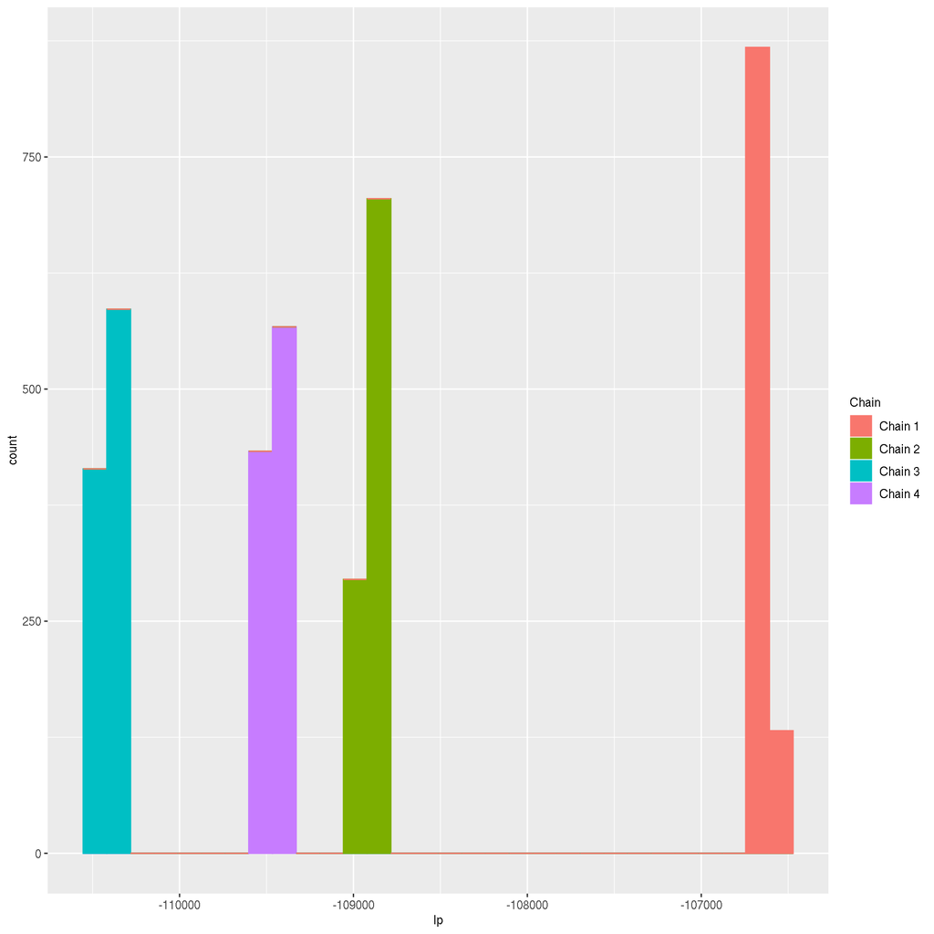

```r
# head(rstan::extract(stan.fit)$"lp__")
#
# tail(rstan::extract(stan.fit)$"lp__")

df = tibble(lp = rstan::extract(stan.fit)$"lp__", Chain = paste0("Chain ", rep(seq_len(4), each = (iter/2))))

ggplot(data = df) +
  geom_histogram(aes(x = lp, col = Chain, fill = Chain))
```

## 4.2 Posterior mean, Monte Carlo standard error, posterior standard deviation

```r
head(summary(stan.fit, pars = c("theta"), probs = c(0.1, 0.9))$summary)
```

```
##                   mean      se_mean          sd          10%         90%
## theta[1,1] 0.257553588 2.520633e-01 0.356801811 4.216106e-04 0.871896330
## theta[1,2] 0.429802285 3.049062e-01 0.431460421 2.065031e-04 0.930021555
## theta[1,3] 0.001198022 1.664309e-05 0.001302427 7.865126e-05 0.002860926
## theta[1,4] 0.203027797 2.465443e-01 0.348875641 1.784210e-04 0.812798651
## theta[1,5] 0.023703180 2.761619e-02 0.039897044 1.370895e-04 0.096027700
## theta[1,6] 0.013842407 9.513603e-03 0.017403513 4.313729e-04 0.037214022
##                  n_eff       Rhat
## theta[1,1]    2.003710 25.7864051
## theta[1,2]    2.002393 35.9658510
## theta[1,3] 6124.044774  0.9997757
## theta[1,4]    2.002403 35.9764379
## theta[1,5]    2.087151  4.7450391
## theta[1,6]    3.346446  1.5508682
```

```r
head(summary(stan.fit, pars = c("beta"), probs = c(0.1, 0.9))$summary)
```

```
##                   mean      se_mean           sd          10%          90%
## beta[1,1] 0.0001358633 9.591548e-05 0.0002140347 1.776339e-06 0.0003822211
## beta[1,2] 0.0013633715 1.600509e-03 0.0022726267 1.320477e-06 0.0053767840
## beta[1,3] 0.1966116733 2.406480e-01 0.3404190343 2.454194e-06 0.7875061764
## beta[1,4] 0.0001528110 1.209520e-04 0.0001939820 1.648817e-06 0.0004657589
## beta[1,5] 0.0015552076 1.821120e-03 0.0025874871 1.363060e-06 0.0061135428
## beta[1,6] 0.0014259558 1.639248e-03 0.0023342327 1.563994e-06 0.0055512688
##              n_eff       Rhat
## beta[1,1] 4.979561   1.296310
## beta[1,2] 2.016230  10.931174
## beta[1,3] 2.001074 156.418818
## beta[1,4] 2.572153   2.034937
## beta[1,5] 2.018734  10.124404
## beta[1,6] 2.027678   8.329725
```

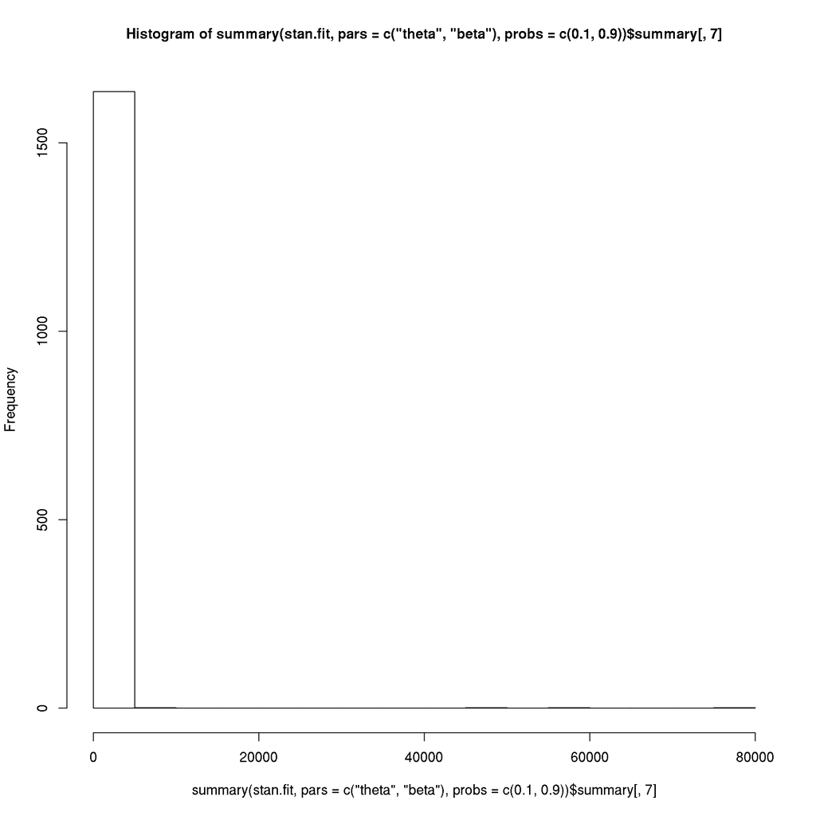

```r
# plot R hat of theta and beta
hist(summary(stan.fit, pars = c("theta", "beta"), probs = c(0.1, 0.9))$summary[,7])
```

## 4.3 Sampler diagnostics

```r
sampler_params = get_sampler_params(stan.fit, inc_warmup = FALSE)
colnames(sampler_params[[1]])
```

```
## [1] "accept_stat__" "stepsize__"    "treedepth__"   "n_leapfrog__"
## [5] "divergent__"   "energy__"
```

```r
mean_accept_stat_by_chain = sapply(sampler_params, function(x) mean(x[, "accept_stat__"]))
mean_accept_stat_by_chain
```

```
## [1] 0.9379419 0.9475154 0.9215002 0.9215263
```

```r
max_treedepth_by_chain = sapply(sampler_params, function(x) max(x[, "treedepth__"]))
max_treedepth_by_chain
```

```
## [1] 6 6 6 8
```

# 5 Visualization

## 5.1 Extract posterior samples

```r
samples = rstan::extract(stan.fit, permuted = TRUE, inc_warmup = FALSE, include = TRUE)# samples is a list
```

## 5.2 Alignment

- Create a Topic $*$ Chain matrix

```r
source("./RFuns/alignmentMatrix.R")
source("./RFuns/thetaAligned.R")
theta = samples$theta
aligned <- alignmentMatrix(theta, mae, K, iter = iter, chain = 4)
theta_aligned <- thetaAligned(theta, K, aligned, iter = iter, chain = 4)
dimnames(theta_aligned)[[2]] = colnames(mae) %>% unlist() %>% as.character()
dimnames(theta_aligned)[[3]] = c(paste0("Topic_", seq(1,K)))
```

```r
# array to a dataframe
theta_all = melt(theta_aligned)
colnames(theta_all) = c("iteration", "Sample", "Topic", "topic.dis")
theta_all$Chain = paste0("Chain ", rep(seq(1, 4), each = (iter/2)))

sam = colData(mae) %>% data.frame()
theta_all$Sample = as.character(theta_all$Sample)
theta_all = left_join(theta_all, sam, by =c("Sample"= "SampleID"))
theta_all$Chain = factor(theta_all$Chain)
theta_all$Topic = factor(theta_all$Topic)
theta_all$immune_group[which(is.na(theta_all$immune_group))] <- "Unknown"
theta_all$immune_group <- factor(theta_all$immune_group)
```

## 5.3 Plot the topic distribution in each chain

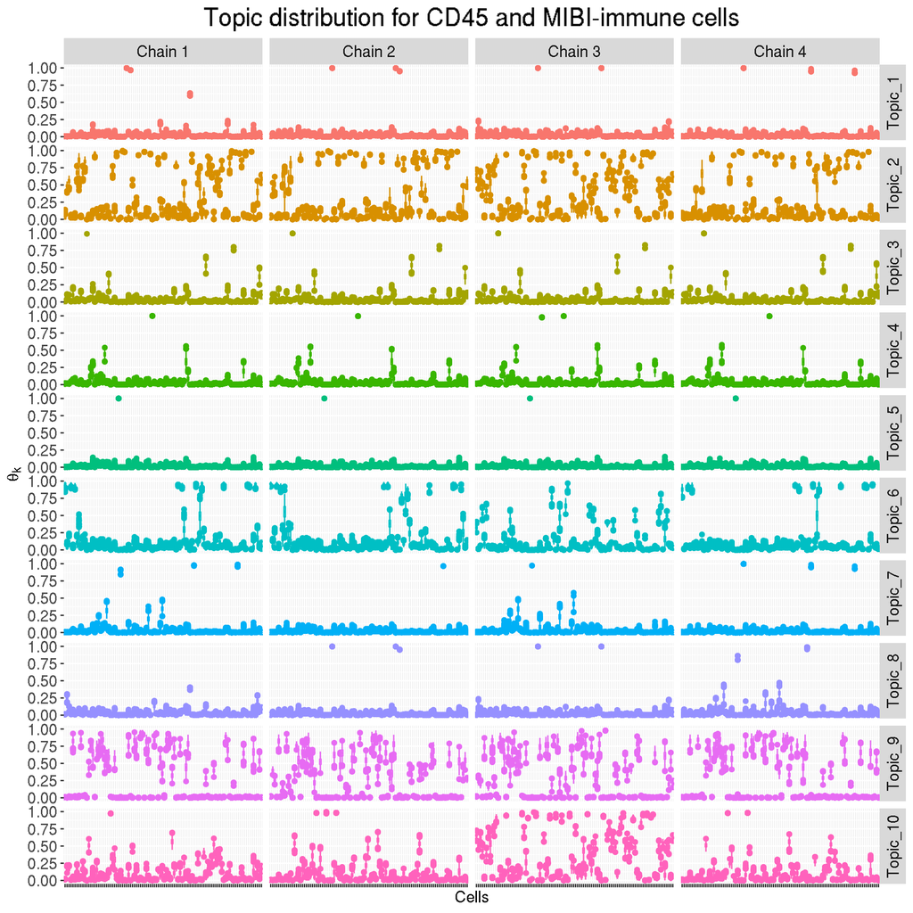

```r
p_chain = ggplot(data = theta_all) +
  geom_boxplot(aes(x = Sample, y = topic.dis,
                   color = Topic, group = Sample)) +
  facet_grid(Topic ~ Chain, scales = "free_x")+
  ylab(bquote(theta[k])) +
  ggtitle("Topic distribution for CD45 and MIBI-immune cells") +
  xlab("Cells") +
  theme(plot.title = element_text(hjust = 0.5, size = 20),
    strip.text.y= element_text(size = 15, angle = 90),
    strip.text.x = element_text(size = 15),
    axis.text.x = element_blank(),
    axis.text.y=element_text(size = 15),
    axis.title = element_text(size = 15),
    legend.position = "none")
p_chain
```

## 5.4 Plot the topic distribution in all chains

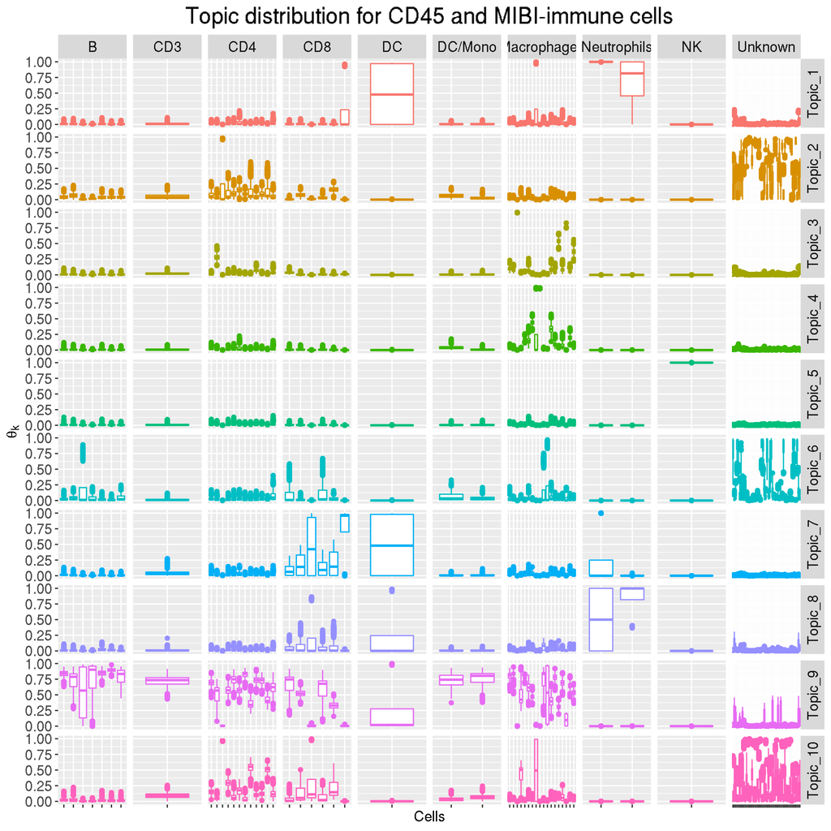

```r
p = ggplot(data = theta_all) +
  geom_boxplot(aes(x = Sample, y = topic.dis,
                   color = Topic, group = Sample)) +
  facet_grid(Topic ~ immune_group, scales = "free_x")+
  ylab(bquote(theta[k])) +
  ggtitle("Topic distribution for CD45 and MIBI-immune cells") +
  xlab("Cells") +
  theme(plot.title = element_text(hjust = 0.5, size = 20),
    strip.text.y= element_text(size = 15, angle = 90),
    strip.text.x = element_text(size = 15),
    axis.text.x = element_blank(),
    axis.text.y=element_text(size = 15),
    axis.title = element_text(size = 15),
    legend.position = "none")
p
```

## 5.5 Marker distribution

```r
source("./RFuns/betaAligned.R")
beta <- samples$beta # an array (iterations *topic * ASV)
beta_aligned <- betaAligned(beta, K, aligned, iter = iter, chain = 4) # an array (iterations *topic * ASV)

# g(beta_k) transformation on beta_k
beta_logit <- beta_aligned
rm(beta_aligned)
for (i in seq_len(nrow(beta_logit))) {
  for (k in seq_len(K)) {
    beta_logit[i, k, ] = log(beta_logit[i, k, ])
    beta_logit[i, k, ] = beta_logit[i, k, ] - mean(beta_logit[i, k, ])
  }
}

# array to data frame
beta_hat <- beta_logit %>%
  melt(varnames = c("iterations", "topic", "marker_ix"), value.name = "beta_logit") %>%
  as_tibble()
beta_hat$marker <- colnames(x)[beta_hat$marker_ix]
rm(beta_logit)

# join rowData with beta_hat
marker_info <- full_join(rowData(mae[["cd45"]]) %>% data.frame(), rowData(mae[["mibi"]]) %>% data.frame())
marker_info$marker <- marker_info$marker_name
# If we use a taxanomy level with NA, we can replace the taxanomy level with one level before this level
#marker_info$Class[which(is.na(marker_info$Class))] = marker_info$Phylum[which(is.na(marker_info$Class))]

beta_hat <- beta_hat %>%
  left_join(marker_info, by = "marker") %>% mutate(topic = paste("Topic", topic))

# sort ASV by the number of ASV per Class (there is no NA, if there is NA, we need to replace by some character to make sure that NA does not dominate on sort)
sorted_marker = names(sort(table(beta_hat$marker_name), decreasing = TRUE))
beta_hat$marker_name <- factor(beta_hat$marker_name)
beta_hat$marker_name <- factor(beta_hat$marker_name, levels = sorted_marker)
beta_hat$marker <- factor(beta_hat$marker)
beta_hat$marker_ix <- factor(beta_hat$marker_ix)
beta_hat$topic <- factor(beta_hat$topic)


beta_summary <- beta_hat %>%
  dplyr::group_by(marker_ix, topic) %>%
  dplyr::summarise(
    marker = marker[1],
    beta_median = median(beta_logit),
    marker_name = marker_name[1],
    hgnc_symbol = hgnc_symbol[1],
    beta_upper = quantile(beta_logit, 0.975),
    beta_lower = quantile(beta_logit, 0.025)
  )

# we plot only 20 marker_name and merge other marker_name to "other"
levels(beta_summary$marker_name) <- c(levels(beta_summary$marker_name), "other")
choose_marker <- c(unique(beta_summary$marker_name[order(beta_summary$beta_median, decreasing = TRUE)])[1:20] %>% as.character(), common_markers)
choose_marker <- unique(choose_marker)
beta_summary$marker_name[!(beta_summary$marker_name %in% choose_marker)] <- "other"
# beta_summary$marker_name[!(beta_summary$marker_name %in% levels(beta_summary$marker_name)[1:30])] <- "other"
beta_summary$marker_name <- droplevels(beta_summary$marker_name)

# we plot all 64 markers (the order was determined by total sum of reads per marker) and color by hgnc_symbol
x_order <- names(sort(colSums(x), decreasing = TRUE))
beta_subset <- beta_summary %>%
  dplyr::filter(marker_name %in% x_order)
beta_subset$marker_ix <- rep(seq_len(nrow(beta_subset) / K), each = K)
```

```r
getPalette = colorRampPalette(brewer.pal(9, "Set1"))
```

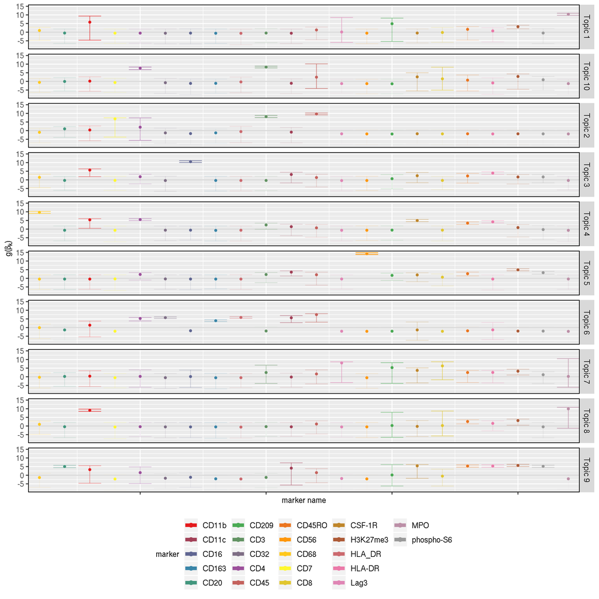

```r
p = ggplot(beta_subset) +
  geom_hline(yintercept = 0, alpha = 0.4, size = 0.5, col = "#999999") +
  geom_point(aes(x = marker_ix, y = beta_median, col = marker_name), size = 1) +
  geom_errorbar(aes(x = marker_ix, alpha = beta_upper, ymax = beta_upper, ymin = beta_lower, col = marker_name), size = 0.4) +
   facet_grid(topic ~ .) +
  scale_color_manual(values = getPalette(length(choose_marker))) +
  scale_alpha(range = c(0.01, 1), breaks = c(1, 2, 3), guide = FALSE) + ## larger values have darker CIs
  scale_x_continuous(expand = c(0, 0)) +
  guides(color = guide_legend(override.aes = list(alpha = 1, size = 2))) +
  labs(x = "marker name", y = expression(paste("g(", beta[k], ")")), col = "marker") +
  theme(panel.border = element_rect(fill = "transparent", size = 0.75),
    axis.text.x = element_blank(),
    strip.text.x = element_blank(),
    legend.position = "bottom")

p
```

# 6 Without including the spatial x-y coordinate data, how well can we predict cell co-location?

```r
theta_summary <- theta_all %>%
  dplyr::group_by(Sample, Topic) %>%
  dplyr::summarise(
    median_theta = median(topic.dis)
  )

theta_summary_assign <- theta_summary %>%
  dplyr::group_by(Sample) %>%
  dplyr::summarise(
    value = max(median_theta),
    Topic = Topic[median_theta == max(median_theta)]
  )
```

The cells have large proportion of topic 1

```r
theta_summary_assign$Sample[theta_summary_assign$Topic == "Topic_1"]
```

```
## [1] "29469_30739"
```

```r
colData(mae[, theta_summary_assign$Sample[theta_summary_assign$Topic == "Topic_1"], ])
```

```
## DataFrame with 1 row and 66 columns
##                SampleID Condition PatientID.x file_name condition.y
##             <character>  <factor>    <factor>  <factor> <character>
## 29469_30739 29469_30739        NA          NA        NA          NA
##             patient_id.y Health.Status      Gender Age.at.Surgery
##              <character>   <character> <character>    <character>
## 29469_30739           NA            NA          NA             NA
##             Menopause.Status Histopathology   T.Staging   N.Staging   M.Staging
##                  <character>    <character> <character> <character> <character>
## 29469_30739               NA             NA          NA          NA          NA
##                   Grade Grade.comment Lymph.Node.Status..L.   Resection
##             <character>   <character>           <character> <character>
## 29469_30739          NA            NA                    NA          NA
##             ER.Status.by.IHC ER.IRS.Score ER.percent.positive.cells.by.IHC
##                  <character>  <character>                      <character>
## 29469_30739               NA           NA                               NA
##             PR.Status.by.IHC PR.IRS.Score PR.percent.positive.cells.by.IHC
##                  <character>  <character>                      <character>
## 29469_30739               NA           NA                               NA
##             HER2.Status.by.IHC HER2.IHC.Score HER2.Status.by.FISH.or.SISH
##                    <character>    <character>                 <character>
## 29469_30739                 NA             NA                          NA
##             Ki.67.percent.positive.cells.by.IHC Clinical.Subtype
##                                     <character>      <character>
## 29469_30739                                  NA               NA
##             Neoadjuvant.Therapy.Received Previous.Cancer.Incidences
##                              <character>                <character>
## 29469_30739                           NA                         NA
##             cellLabelInImage  cellSize   tumorYN tumorCluster immuneCluster
##                    <numeric> <numeric> <numeric>    <numeric>     <numeric>
## 29469_30739             2460       827         0            0            79
##             tumor_group immune_group PatientID.y      YEAR ANON_ID_ONCOSHARE
##             <character>  <character>   <numeric> <numeric>         <numeric>
## 29469_30739      Immune  Neutrophils       30739      2003             12164
##             AGE_AT_DX    YEARDX     STAGE     SITE_02   LATERAL     GRADE
##             <numeric> <numeric> <numeric> <character> <numeric> <numeric>
## 29469_30739        52      2002        10        C505         1         3
##                 TCODE_P     NCODE_P     MCODE_P      AJCC_P        ER        PR
##             <character> <character> <character> <character> <numeric> <numeric>
## 29469_30739          NA          NA          NA          NA         2         2
##               HER2NEU CS_TUM_SIZE RESULT_GENE_1 RESULT_MUTATION_1
##             <numeric> <character>   <character>       <character>
## 29469_30739         2          NA            NA                NA
##             TEST_OFFERING_1 RESULT_GENE_2 RESULT_MUTATION_2 TEST_OFFERING_2
##                 <character>   <character>       <character>     <character>
## 29469_30739              NA            NA                NA              NA
##             MYRIAD_TEST_RESULT RECURRENCE_LABEL TIL_score
##                    <character>      <character> <numeric>
## 29469_30739                 NA         NEGATIVE         3
##             Survival_days_capped_2016.1.1  Censored
##                                 <numeric> <numeric>
## 29469_30739                          4761         1
```

```r
colData(mae[, theta_summary_assign$Sample[theta_summary_assign$Topic == "Topic_2"], ])
```

```
## DataFrame with 38 rows and 66 columns
##                SampleID Condition PatientID.x                  file_name
##             <character>  <factor>    <factor>                   <factor>
## 10139_BB217 10139_BB217         T       BB217 T_BB217_CD45_clustered.fcs
## 10401_BB217 10401_BB217         T       BB217 T_BB217_CD45_clustered.fcs
## 1111_BB090   1111_BB090         N       BB090 N_BB090_CD45_clustered.fcs
## 11175_BB230 11175_BB230         T       BB230 T_BB230_CD45_clustered.fcs
## 1208_BB090   1208_BB090         N       BB090 N_BB090_CD45_clustered.fcs
## ...                 ...       ...         ...                        ...
## 8809_BB209   8809_BB209         T       BB209 T_BB209_CD45_clustered.fcs
## 8925_BB209   8925_BB209         T       BB209 T_BB209_CD45_clustered.fcs
## 9059_BB209   9059_BB209         T       BB209 T_BB209_CD45_clustered.fcs
## 9406_BB217   9406_BB217         T       BB217 T_BB217_CD45_clustered.fcs
## 9954_BB217   9954_BB217         T       BB217 T_BB217_CD45_clustered.fcs
##             condition.y patient_id.y         Health.Status      Gender
##             <character>  <character>           <character> <character>
## 10139_BB217           T        BB217 Breast cancer patient           F
## 10401_BB217           T        BB217 Breast cancer patient           F
## 1111_BB090            N        BB090 Breast cancer patient           F
## 11175_BB230           T        BB230 Breast cancer patient           F
## 1208_BB090            N        BB090 Breast cancer patient           F
## ...                 ...          ...                   ...         ...
## 8809_BB209            T        BB209 Breast cancer patient           F
## 8925_BB209            T        BB209 Breast cancer patient           F
## 9059_BB209            T        BB209 Breast cancer patient           F
## 9406_BB217            T        BB217 Breast cancer patient           F
## 9954_BB217            T        BB217 Breast cancer patient           F
##             Age.at.Surgery Menopause.Status           Histopathology
##                <character>      <character>              <character>
## 10139_BB217             29              pre InvasiveLobularCarcinoma
## 10401_BB217             29              pre InvasiveLobularCarcinoma
## 1111_BB090              61             post  InvasiveDuctalCarcinoma
## 11175_BB230             57             post  InvasiveDuctalCarcinoma
## 1208_BB090              61             post  InvasiveDuctalCarcinoma
## ...                    ...              ...                      ...
## 8809_BB209              53              pre  InvasiveDuctalCarcinoma
## 8925_BB209              53              pre  InvasiveDuctalCarcinoma
## 9059_BB209              53              pre  InvasiveDuctalCarcinoma
## 9406_BB217              29              pre InvasiveLobularCarcinoma
## 9954_BB217              29              pre InvasiveLobularCarcinoma
```

[output cut: 167 more lines]

```
## 9406_BB217               NA                 NA               NA        NA
## 9954_BB217               NA                 NA               NA        NA
##             Survival_days_capped_2016.1.1  Censored
##                                 <numeric> <numeric>
## 10139_BB217                            NA        NA
## 10401_BB217                            NA        NA
## 1111_BB090                             NA        NA
## 11175_BB230                            NA        NA
## 1208_BB090                             NA        NA
## ...                                   ...       ...
## 8809_BB209                             NA        NA
## 8925_BB209                             NA        NA
## 9059_BB209                             NA        NA
## 9406_BB217                             NA        NA
## 9954_BB217                             NA        NA
```

```r
colData(mae[, theta_summary_assign$Sample[theta_summary_assign$Topic == "Topic_3"], ])
```

```
## DataFrame with 3 rows and 66 columns
##                SampleID Condition PatientID.x file_name condition.y
##             <character>  <factor>    <factor>  <factor> <character>
## 12914_30753 12914_30753        NA          NA        NA          NA
## 6305_30847   6305_30847        NA          NA        NA          NA
## 7935_30783   7935_30783        NA          NA        NA          NA
##             patient_id.y Health.Status      Gender Age.at.Surgery
##              <character>   <character> <character>    <character>
## 12914_30753           NA            NA          NA             NA
## 6305_30847            NA            NA          NA             NA
## 7935_30783            NA            NA          NA             NA
##             Menopause.Status Histopathology   T.Staging   N.Staging   M.Staging
##                  <character>    <character> <character> <character> <character>
## 12914_30753               NA             NA          NA          NA          NA
## 6305_30847                NA             NA          NA          NA          NA
## 7935_30783                NA             NA          NA          NA          NA
##                   Grade Grade.comment Lymph.Node.Status..L.   Resection
##             <character>   <character>           <character> <character>
## 12914_30753          NA            NA                    NA          NA
## 6305_30847           NA            NA                    NA          NA
## 7935_30783           NA            NA                    NA          NA
##             ER.Status.by.IHC ER.IRS.Score ER.percent.positive.cells.by.IHC
##                  <character>  <character>                      <character>
## 12914_30753               NA           NA                               NA
## 6305_30847                NA           NA                               NA
## 7935_30783                NA           NA                               NA
##             PR.Status.by.IHC PR.IRS.Score PR.percent.positive.cells.by.IHC
##                  <character>  <character>                      <character>
## 12914_30753               NA           NA                               NA
## 6305_30847                NA           NA                               NA
## 7935_30783                NA           NA                               NA
##             HER2.Status.by.IHC HER2.IHC.Score HER2.Status.by.FISH.or.SISH
##                    <character>    <character>                 <character>
## 12914_30753                 NA             NA                          NA
## 6305_30847                  NA             NA                          NA
## 7935_30783                  NA             NA                          NA
##             Ki.67.percent.positive.cells.by.IHC Clinical.Subtype
##                                     <character>      <character>
## 12914_30753                                  NA               NA
## 6305_30847                                   NA               NA
```

[output cut: 31 more lines]

```
##              TEST_OFFERING_1 RESULT_GENE_2 RESULT_MUTATION_2 TEST_OFFERING_2
##                  <character>   <character>       <character>     <character>
## 12914_30753 BRACAnalysisLR01            NA                NA              NA
## 6305_30847                NA            NA                NA              NA
## 7935_30783                NA            NA                NA              NA
##                              MYRIAD_TEST_RESULT RECURRENCE_LABEL TIL_score
##                                     <character>      <character> <numeric>
## 12914_30753 POSITIVE FOR A DELETERIOUS MUTATION         NEGATIVE       NaN
## 6305_30847                                   NA         NEGATIVE       2.5
## 7935_30783                                   NA               NA         3
##             Survival_days_capped_2016.1.1  Censored
##                                 <numeric> <numeric>
## 12914_30753                          4353         1
## 6305_30847                           2275         1
## 7935_30783                           3767         1
```